# Summary Report

**Performance Metrics Cheat Sheet**

|  | Predicted Positive | Predicted Negative |
| --- | --- | --- |
| Real Positive | TP | FN |
| Real Negative | FP | TN |

$\begin{aligned} {\text{Prevalence}} = \frac{\text{TP + FN}}{\text{TP + FP + TN + FN}} \end{aligned}$

$\begin{aligned} {\text{PPCR (Predicted Positives Condition Rate)}} = \frac{\text{TP + FP}}{\text{TP + FP + TN + FN}} \end{aligned}$

$\begin{aligned} \text{Sensitivity (Recall, True Positive Rate)} = \frac{\text{TP}}{\text{TP + FN}} = \frac{\text{TP}}{\text{Real Positives}} = \text{Prob( Predicted Positive | Real Positive )} \end{aligned}$

$\begin{aligned} \text{Specificity (True Negative Rate)} = \frac{\text{TN}}{\text{TN + FP}} = \frac{\text{TN}}{\text{Real Negatives}} = \text{Prob( Predicted Negative | Real Negative )} \end{aligned}$

$\begin{aligned} \text{PPV (Precision)} = \frac{\text{TP}}{\text{TP + FP}} = \frac{\text{TP}}{\text{Predicted Positives}} = \text{Prob( Real Positive | Predicted Positive )} \end{aligned}$

$\begin{aligned} \text{NPV} = \frac{\text{TN}}{\text{TN + FN}} = \frac{\text{TN}}{\text{Predicted Negatives}} = \text{Prob( Real Negative | Predicted Negative )} \end{aligned}$

$\begin{aligned} \text{Lift} = \frac{\text{PPV}}{\text{Prevalence}} = \frac{\cfrac{\text{TP}}{\text{TP + FP}}}{\cfrac{\text{TP + FN}}{\text{TP + FP + TN + FN}}} \end{aligned}$

$\begin{aligned} \text{Net Benefit} = \frac{\text{TP}}{\text{TP + FP + TN + FN}} - \frac{\text{FP}}{\text{TP + FP + TN + FN}} * {\frac{{p_{t}}}{{1 - p_{t}}}} \end{aligned}$

| Prevalence |
| --- |
| 0.333333333333333 |

# Calibration

## Smooth

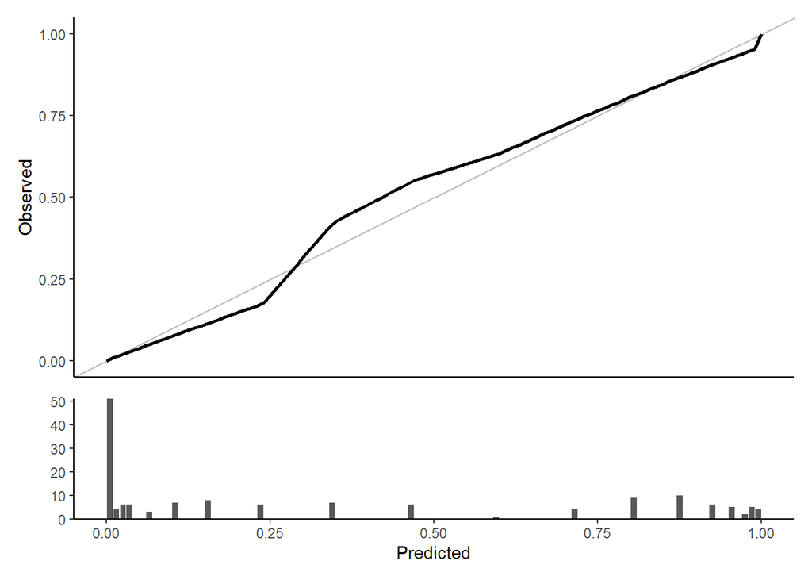

## Discrete

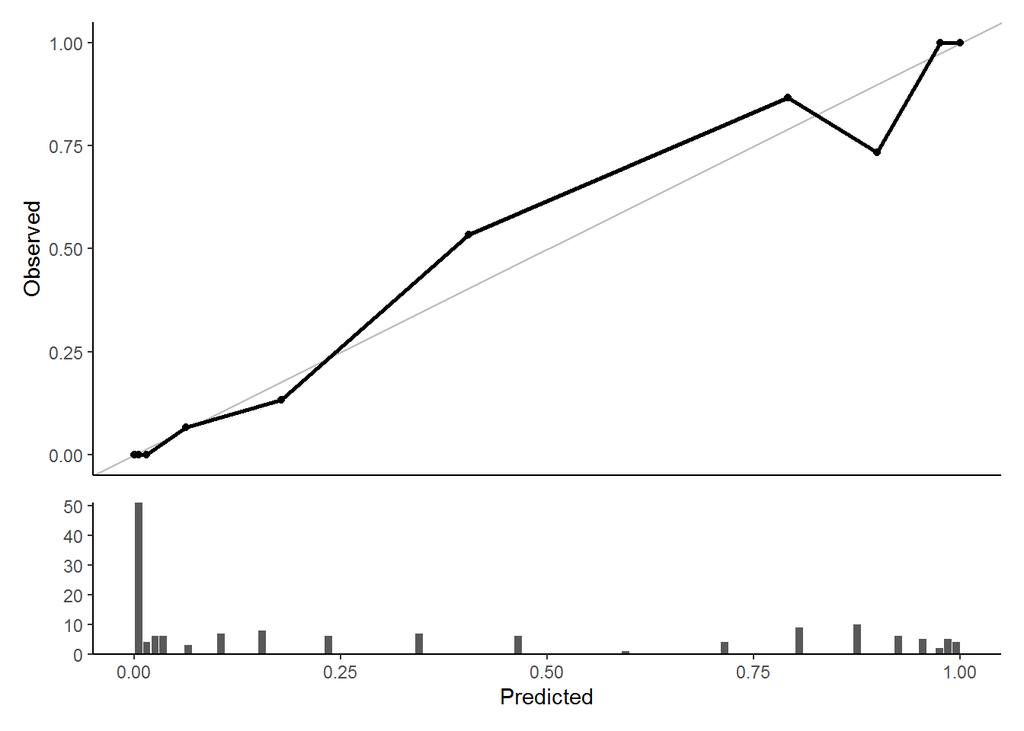

# Probability Threshold Dependent Performance Metrics

| AUROC |
| --- |
| 0.9586 |

## By Probability Threshold

### Performance Metrics Curves

#### ROC

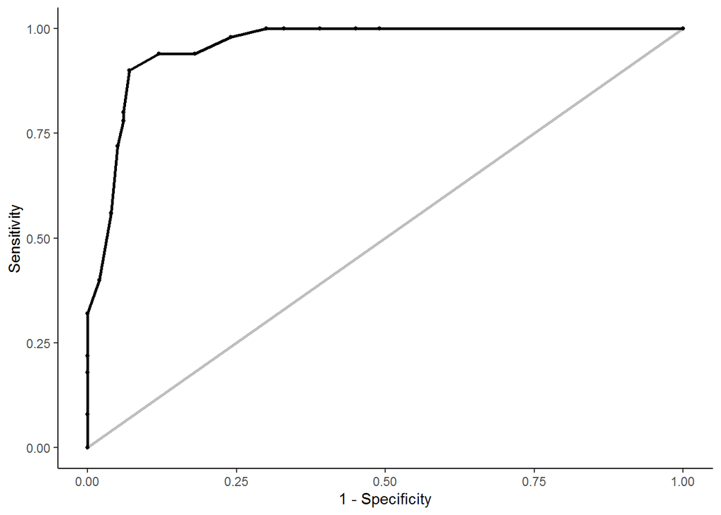

#### Lift

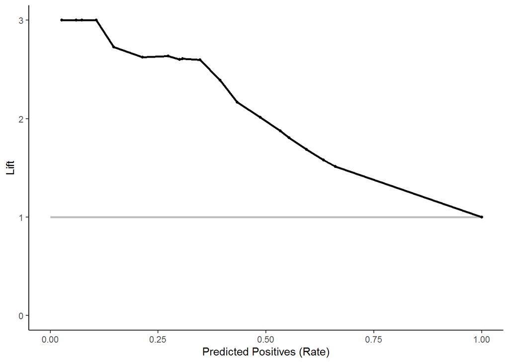

#### Precision Recall

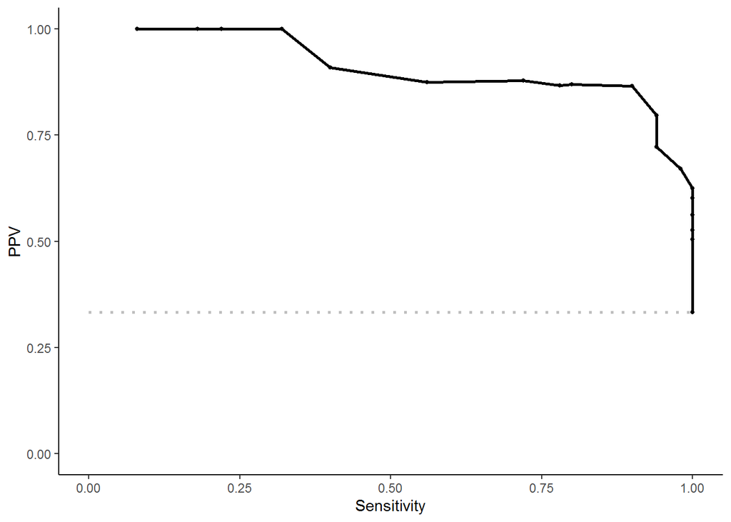

#### Gains

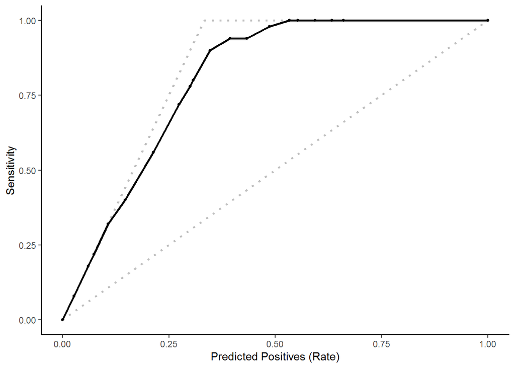

#### Decision

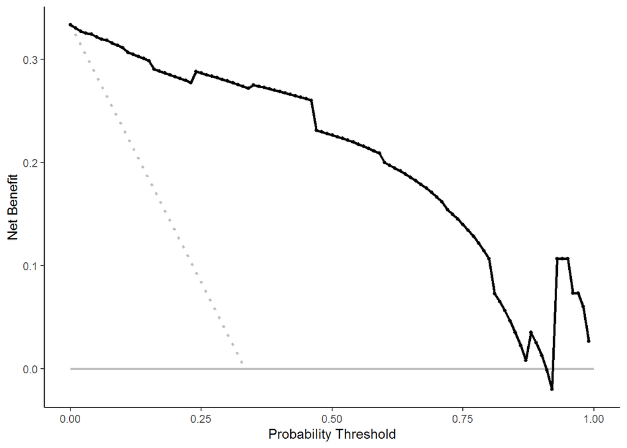

### Performance Table

Probability Threshold

| Probability Threshold | Sens | Spec | PPV | NPV | Lift | Net Benefit | Predicted Positives |
| --- | --- | --- | --- | --- | --- | --- | --- |
| 0 | 1 | 0 | 0.333333333333333 | NaN | 1 | 0.333333333333333 | 1 |
| 0.01 | 1 | 0.51 | 0.505050505050505 | 1 | 1.51515151515152 | 0.33003367003367 | 0.66 |
| 0.02 | 1 | 0.55 | 0.526315789473684 | 1 | 1.57894736842105 | 0.327210884353741 | 0.633333333333333 |
| 0.03 | 1 | 0.61 | 0.561797752808989 | 1 | 1.68539325842697 | 0.325292096219931 | 0.593333333333333 |
| 0.04 | 1 | 0.67 | 0.602409638554217 | 1 | 1.80722891566265 | 0.324166666666667 | 0.553333333333333 |
| 0.05 | 1 | 0.67 | 0.602409638554217 | 1 | 1.80722891566265 | 0.321754385964912 | 0.553333333333333 |
| 0.06 | 1 | 0.67 | 0.602409638554217 | 1 | 1.80722891566265 | 0.319290780141844 | 0.553333333333333 |
| 0.07 | 1 | 0.7 | 0.625 | 1 | 1.875 | 0.318279569892473 | 0.533333333333333 |
| 0.08 | 1 | 0.7 | 0.625 | 1 | 1.875 | 0.315942028985507 | 0.533333333333333 |
| 0.09 | 1 | 0.7 | 0.625 | 1 | 1.875 | 0.313553113553114 | 0.533333333333333 |

[output cut: 91 more lines]

## By Predicted Positives Condition Rate (PPCR)

### Performance Metrics Curves

#### ROC

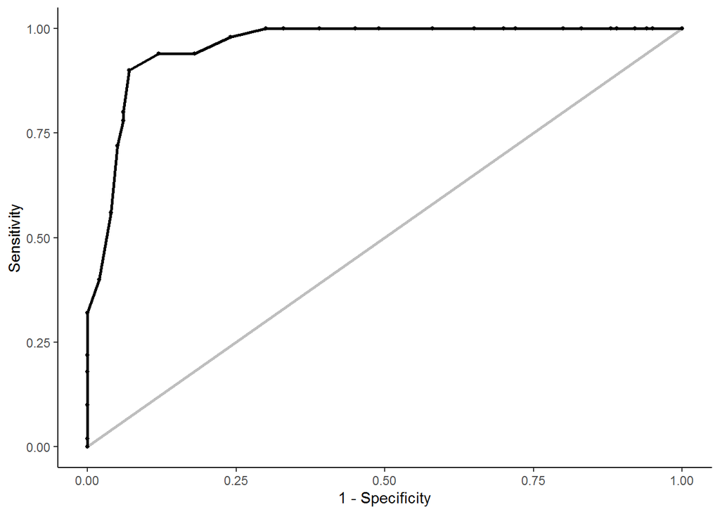

#### Lift

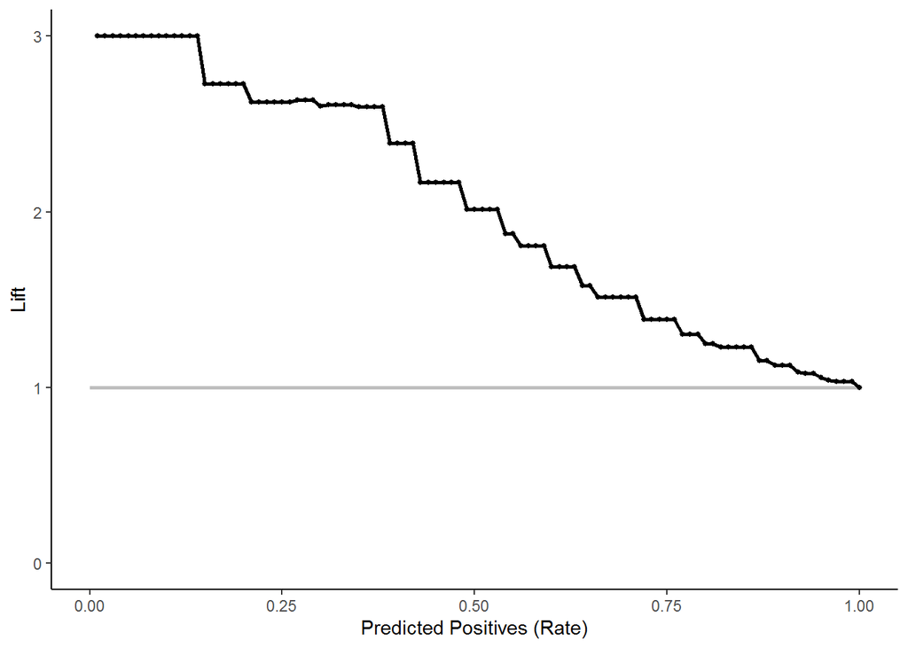

#### Precision Recall

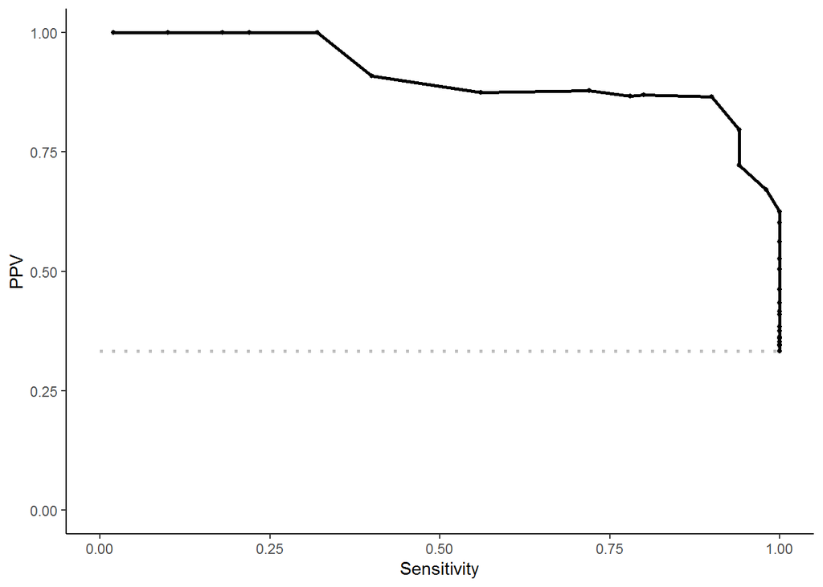

#### Gains

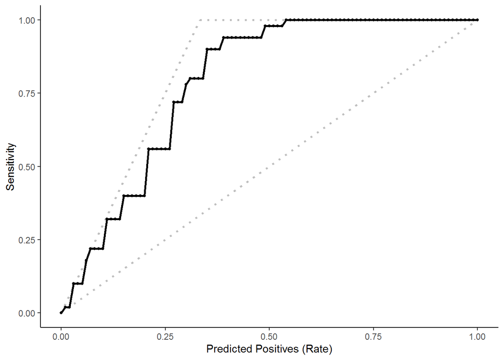

#### Decision

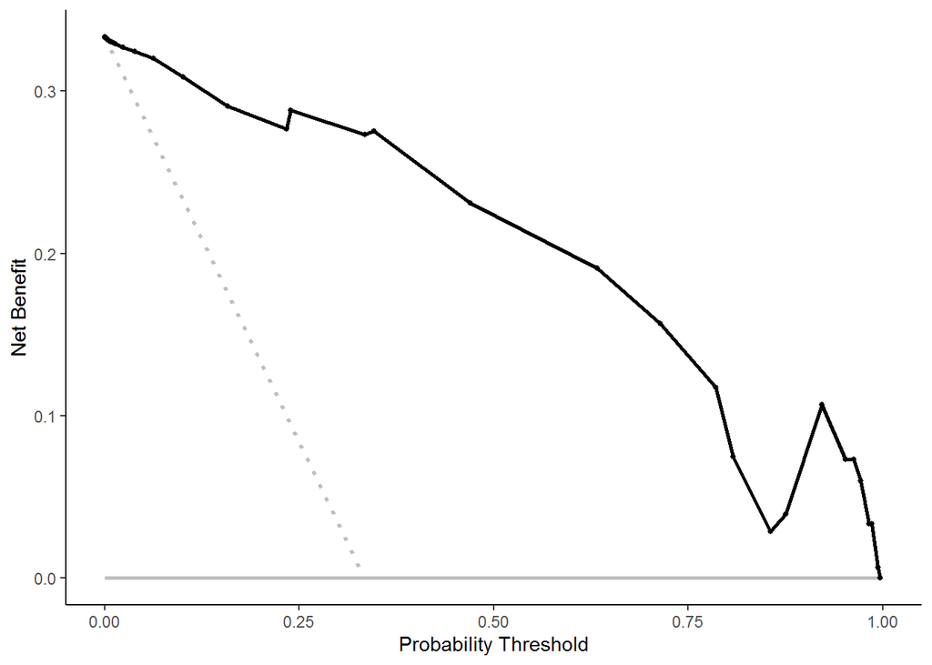

### Performance Table

Predicted Positives Condition Rate (PPCR)

| Predicted Positives | Sens | Spec | PPV | NPV | Lift | Net Benefit |
| --- | --- | --- | --- | --- | --- | --- |
| 0 | 0 | 1 | NaN | 0.666666666666667 | NaN | 0 |
| 0.01 | 0.02 | 1 | 1 | 0.671140939597315 | 3 | 0.00666666666666667 |
| 0.02 | 0.02 | 1 | 1 | 0.671140939597315 | 3 | 0.00666666666666667 |
| 0.03 | 0.1 | 1 | 1 | 0.689655172413793 | 3 | 0.0333333333333333 |
| 0.04 | 0.1 | 1 | 1 | 0.689655172413793 | 3 | 0.0333333333333333 |
| 0.05 | 0.1 | 1 | 1 | 0.689655172413793 | 3 | 0.0333333333333333 |
| 0.06 | 0.18 | 1 | 1 | 0.709219858156028 | 3 | 0.06 |
| 0.07 | 0.22 | 1 | 1 | 0.719424460431655 | 3 | 0.0733333333333333 |
| 0.08 | 0.22 | 1 | 1 | 0.719424460431655 | 3 | 0.0733333333333333 |
| 0.09 | 0.22 | 1 | 1 | 0.719424460431655 | 3 | 0.0733333333333333 |

[output cut: 91 more lines]